# Cárdenas, Kim, Tureson_Peer-Review Posting

2020-10-30

# Questions

Question One:

Are expectant fathers' testosterone levels during the prenatal period explained by between-level or within-level expectant mothers' testosterone (i.e., hormonal synchrony). More specifically, do expectant mothers' testosterone levels during the prenatal period predict expectant fathers' testosterone levels during the same period? Of note, we assess between and within-level testosterone in as this is a common practice in hormonal literature (see Saxbe et al., 2017).

Question Two:

Does couples' prenatal hormonal synchrony predict fathers' postpartum satisfaction in the couple relationship?

# Relevant background

Lower testosterone levels are associated with parent nurturing behavior (Alvergne et al., 2009; van Anders, 2013). Expectant fathers in coupled relationships show decreases in testosterone during the prenatal period (Edelstein et al., 2015). Couples in romantic relationships tend to show physiological linkage, including in the sympathetic nervous system (i.e., heart rate) and the hypothalamic-pituitary system (i.e., hormones; Timmons et al., 2015). During the prenatal period, hormonal synchrony between mothers and fathers is associated with more significant investment in the partner and infant relationship (Saxbe et al., 2017). However, less is known whether couple hormonal synchrony across the transition to parenthood (prenatal and postpartum) is positively correlated with relationship satisfaction above baseline couple relationship satisfaction levels. Given that testosterone fluctuates over the transition to parenthood and that the couple relationship is predictive of hormonal synchrony, multilevel modeling will assess testosterone between and within dyads.

# Nesting structure of the data

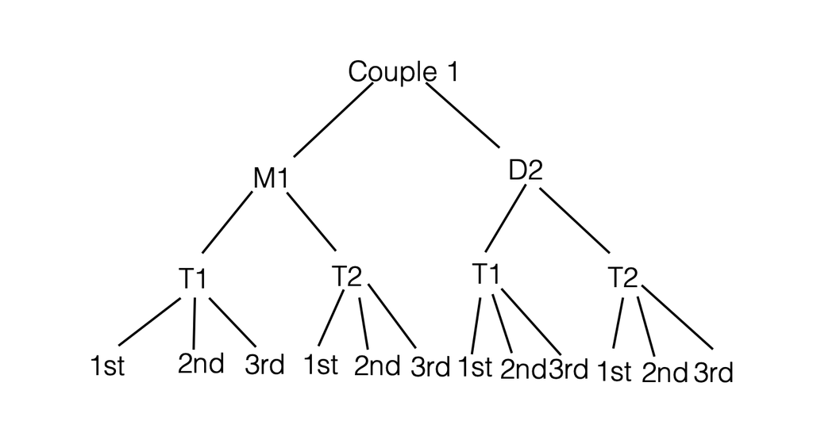

```r
knitr::include_graphics("/Users/sofiacardenas/Desktop/MLM(psyc575)/Final_Project/Data.png")
```

# Testosterone sampling

To provide more detail, during the prenatal and postpartum visits, both mothers and fathers provide six 1mL samples of saliva. Participants are given 5 minutes to passively drool down a little straw until the collection tube fills halfway. Samples are collected at about 20-minute intervals (exact intervals can be found in each protocol), and the exact start and finish times are recorded by research assistants. These saliva samples are assessed to measure hormone levels (testosterone). We do not go into detail on processing in this document, but we will provide more information at our presentation. (stay tuned...!)

# A preliminary plan for statistical analysis

We first want to note that we define hormonal synchrony as mothers' testosterone predicting fathers' testosterone. Question 1 plan for statistical analysis:

Broadly, for testing our first aim (expectant fathers' testosterone levels during the prenatal period are explained by within couple linkage), a two-level MLM model will be used. At Level 1 (the individual-level), our outcome variable was fathers' mean testosterone levels from the first visit (prenatal). We will include one predictor: the mothers' testosterone level from that same visit. Given that we expect each couple is its unique nested unit, we will allow slopes to vary for expectant mothers' prenatal testosterone.

Question 2 plan for statistical analysis:

To test our second aim (couples' prenatal partner synchrony related to fathers' postpartum satisfaction in the couple relationship), we will run a separate model with couples' prenatal synchrony as a predictor of postpartum relationship satisfaction.

# Repository statement

The data analytic scripts and supplemental materials for this project will be available at https://github.com/sicarden/Synchrony_MLM_Fall2020.git.

# References

Alvergne, A., Faurie, C., & Raymond, M. (2009). Variation in testosterone levels and male reproductive effort: insight from a polygynous human population. Horm. Behav. 56,491–497.

Edelstein, R.S., Wardecker, B.M., Chopik, W.J., Moors, A.C., Shipman, E.L., & Lin, N.J. (2015). Prenatal hormones in first-time expectant parents: Longitudinal changes and within-couple correlations. Am. J. Hum. Biol. 27, 317–325.

Saxbe, D.E., Edelstein, R.S., Lyden, H.M., Wardecker, B.M., Chopik, W.J., & Moors, A.C. (2017). Fathers’decline in testosterone and synchrony with partner testosterone during pregnancy predicts greater postpartum relationship investment. Hormones and Behavior, 90, 39–47. https://doi.org/10.1016/j.yhbeh.2016.07.005

Timmons, A.C., Margolin, G., & Saxbe, D.E. (2015). Physiological linkage in couples and its implications forindividual and interpersonal functioning: A literature review. J. Fam.Psychol.29, 720–731.

van Anders, S.M. (2013). Beyond masculinity: testosterone, gender/sex, and human social behavior in a comparative context. Front. Neuroendocrinol. 34(3), 198–210.

# Load packages

```r
# Add additional packages you need
# To install a package, run the following ONCE (and only once on your computer)
# install.packages("psych")
library(here)  # makes reading data more consistent
```

```r
library(tidyverse)  # for data manipulation and plotting
library(haven)  # for importing SPSS/SAS/Stata data
library(brms)  # for Bayesian multilevel analysis
library(lattice)  # for dotplot (working with lme4)
library(sjPlot)  # for plotting effects
library(broom.mixed)  # for summarizing results
library(interactions)  # for plotting interactions
library(modelsummary)  # for making tables
library(psych)
# Add the following so that the LOO will be included in the msummary table
msummary_mixed <- function(models, coef_map = NULL, add_rows = NULL, ...) {
  if (is.null(coef_map)) {
    if (!"list" %in% class(models)) {
      models <- list(models)
    }
    for (model in models) {
      coef_map <- union(coef_map, tidy(model)$term)
    }
  }
  ranef_index <- grep("^(sd|cor)__", x = coef_map)
  coef_map <- c(coef_map[-ranef_index], coef_map[ranef_index])
  names(coef_map) <- coef_map
library(dplyr)
  rows <- data.frame(term = c("Fixed Effects", "Random Effects"))
  rows <- cbind(rows, rbind(rep("", length(models)),
                            rep("", length(models))))
  length_fes <- length(coef_map) - length(ranef_index)
  attr(rows, 'position') <- c(1, (length_fes + 1) * 2)
  modelsummary::msummary(models, coef_map = coef_map, add_rows = rows, ...)
}
theme_set(theme_bw())  # Theme; just my personal preference
```

# Import data

```r
library(foreign)
df <- read.spss("MLM_10.28.20.sav", use.value.label=TRUE, to.data.frame=TRUE)
```

# Convert wide data to long format

```r
# Using the new `tidyr::pivot_longer()` function
df_LONG <- df %>%
  pivot_longer(
    c(Mompn1:Mompn3, Dadpn1:Dadpn3), # variables that are repeated measures
    # Convert 8 columns to 3: 2 columns each for anti/read (.value), and
    # one column for time
    names_to = c(".value", "Testo_Measurement"),
    # Extract the names "anti"/"read" from the names of the variables for the
    # value columns, and then the number to the "time" column
    names_pattern = "(Mompn|Dadpn)([1-3])",
    # Convert the "time" column to integers
    names_transform = list(time = as.integer)
  )
df_LONG %>%
  select(CoupID, Testo_Measurement, Mompn,Dadpn, everything())
```

[output not shown]

# Make variables for between and within variance for prenatal testosterone for expectant mothers

```r
df_LONG <- df_LONG %>%
  group_by(CoupID) %>%
  # The `across()` function can be used to operate the same procedure on
  # multiple variables
  mutate(across(c(Mompn),
                # The `.` means the variable to be operated on
                list("pmc" = ~ . - mean(., na.rm = TRUE)))) %>%
  ungroup()
```

# Variable key

"Mompn_pmc" is the person-mean centered prenatal testosterone level for expectant moms. "Testo1pn_Average" is the person-mean prenatal testosterone level for expectant moms. "Dadpn"" is prenatal testosterone level for expectant dads.

# Model equations for question 1 multilevel analysis

Within-person:
$$\text{Dadpn}_{ti} = \beta_{0i} + \beta_{1j} \text{Mompn_pmc}_{ti} + e_{ti}$$
Between-person:
$$\beta_{0i} = \gamma_{00} + \gamma_{01} \text{Testo1pn_Average}_{i} + u_{0i}\\
\beta_{1i} = \gamma_{10} + u_{1i}\\$$

# Making unconditional models for all variables

```r
m0_Model_daddy <- brm(Dadpn ~ (1 | CoupID), data = df_LONG,
               seed = 2152)
m0_Model_daddy
```

```
##  Family: gaussian
##   Links: mu = identity; sigma = identity
## Formula: Dadpn ~ (1 | CoupID)
##    Data: df_LONG (Number of observations: 225)
## Samples: 4 chains, each with iter = 2000; warmup = 1000; thin = 1;
##          total post-warmup samples = 4000
##
## Group-Level Effects:
## ~CoupID (Number of levels: 76)
##               Estimate Est.Error l-95% CI u-95% CI Rhat Bulk_ESS Tail_ESS
## sd(Intercept)    23.90      2.52    19.40    29.27 1.00     1552     2026
##
## Population-Level Effects:
##           Estimate Est.Error l-95% CI u-95% CI Rhat Bulk_ESS Tail_ESS
## Intercept    57.72      3.02    51.70    63.72 1.00     1597     2216
##
## Family Specific Parameters:
##       Estimate Est.Error l-95% CI u-95% CI Rhat Bulk_ESS Tail_ESS
## sigma    19.80      1.18    17.67    22.21 1.00     3253     3022
##
## Samples were drawn using sampling(NUTS). For each parameter, Bulk_ESS
## and Tail_ESS are effective sample size measures, and Rhat is the potential
## scale reduction factor on split chains (at convergence, Rhat = 1).
```

```r
# Use family = bernoulli for a binary outcome; to be discussed in a later week
m0_Mompn_pmc <- brm(Mompn_pmc ~ (1 | CoupID), data = df_LONG,
               seed = 2152)
m0_Mompn_pmc
```

```
##  Family: gaussian
##   Links: mu = identity; sigma = identity
## Formula: Mompn_pmc ~ (1 | CoupID)
##    Data: df_LONG (Number of observations: 225)
## Samples: 4 chains, each with iter = 2000; warmup = 1000; thin = 1;
##          total post-warmup samples = 4000
##
## Group-Level Effects:
## ~CoupID (Number of levels: 77)
##               Estimate Est.Error l-95% CI u-95% CI Rhat Bulk_ESS Tail_ESS
## sd(Intercept)     0.35      0.27     0.01     1.01 1.00     3604     2024
##
## Population-Level Effects:
##           Estimate Est.Error l-95% CI u-95% CI Rhat Bulk_ESS Tail_ESS
## Intercept    -0.00      0.44    -0.85     0.85 1.00     7014     2903
##
## Family Specific Parameters:
##       Estimate Est.Error l-95% CI u-95% CI Rhat Bulk_ESS Tail_ESS
## sigma     6.44      0.31     5.89     7.10 1.00     6032     2750
##
## Samples were drawn using sampling(NUTS). For each parameter, Bulk_ESS
## and Tail_ESS are effective sample size measures, and Rhat is the potential
## scale reduction factor on split chains (at convergence, Rhat = 1).
```

```r
# Use family = bernoulli for a binary outcome; to be discussed in a later week
m0_Testo1pn_Average <- brm(Testo1pn_Average ~ (1 | CoupID), data = df_LONG,
               seed = 2152)
m0_Testo1pn_Average
```

```
##  Family: gaussian
##   Links: mu = identity; sigma = identity
## Formula: Testo1pn_Average ~ (1 | CoupID)
##    Data: df_LONG (Number of observations: 216)
## Samples: 4 chains, each with iter = 2000; warmup = 1000; thin = 1;
##          total post-warmup samples = 4000
##
## Group-Level Effects:
## ~CoupID (Number of levels: 72)
##               Estimate Est.Error l-95% CI u-95% CI Rhat Bulk_ESS Tail_ESS
## sd(Intercept)     8.73      1.12     6.93     9.79 3.00        5       25
##
## Population-Level Effects:
##           Estimate Est.Error l-95% CI u-95% CI Rhat Bulk_ESS Tail_ESS
## Intercept    12.78      1.84    10.45    14.86 3.31        4       12
##
## Family Specific Parameters:
##       Estimate Est.Error l-95% CI u-95% CI Rhat Bulk_ESS Tail_ESS
## sigma     0.00      0.00     0.00     0.00 3.02        5       11
##
## Samples were drawn using sampling(NUTS). For each parameter, Bulk_ESS
## and Tail_ESS are effective sample size measures, and Rhat is the potential
## scale reduction factor on split chains (at convergence, Rhat = 1).
```

# Using unconditional models to assess intra-class correlation and decompose variance

```r
# Warning: Rows containing NAs were excluded from the model.
# Daddy (expectant dad-testosterone)
post_daddy <- posterior_samples(m0_Model_daddy, pars = c("sd", "sigma"))

# Posterior of ICC: tau_0^2 / (tau_0^2 + sigma^2)
icc_samples_daddy <- post_daddy$sd_CoupID__Intercept^2 /
  (post_daddy$sd_CoupID__Intercept^2 + post_daddy$sigma^2)

# Warning: Rows containing NAs were excluded from the model.
# Mommy_within (expectant mother-testosterone)
post_mommy_within <- posterior_samples(m0_Mompn_pmc, pars = c("sd", "sigma"))

# Posterior of ICC: tau_0^2 / (tau_0^2 + sigma^2)
icc_samples_mommy_within <- post_mommy_within$sd_CoupID__Intercept^2 /
  (post_mommy_within$sd_CoupID__Intercept^2 + post_mommy_within$sigma^2)

# Warning: Rows containing NAs were excluded from the model.
# Mommy_between (expectant mother-testosterone)
post_mommy_between <- posterior_samples(m0_Testo1pn_Average, pars = c("sd", "sigma"))

# Posterior of ICC: tau_0^2 / (tau_0^2 + sigma^2)
icc_samples_mommy_betwewen <- post_mommy_between$sd_CoupID__Intercept^2 /
  (post_mommy_between$sd_CoupID__Intercept^2 + post_mommy_between$sigma^2)

# Print ICCs
c(daddy = mean(icc_samples_daddy),mommy_within = mean(icc_samples_mommy_within), mommy_between = mean(icc_samples_mommy_betwewen))
```

```
##         daddy  mommy_within mommy_between
##    0.58974375    0.00470971    1.00000000
```

# Question 1 MLM model

```r
Model_daddy <- brm(Dadpn ~ Testo1pn_Average + Mompn_pmc + (Mompn_pmc | CoupID),
               seed = 2152,
               control = list(max_treedepth = 15, adapt_delta = .995),
               iter = 4000,

                       data = df_LONG)
```

# Question 1 MLM model results

```r
Model_daddy
```

```
##  Family: gaussian
##   Links: mu = identity; sigma = identity
## Formula: Dadpn ~ Testo1pn_Average + Mompn_pmc + (Mompn_pmc | CoupID)
##    Data: df_LONG (Number of observations: 214)
## Samples: 4 chains, each with iter = 4000; warmup = 2000; thin = 1;
##          total post-warmup samples = 8000
##
## Group-Level Effects:
## ~CoupID (Number of levels: 72)
##                          Estimate Est.Error l-95% CI u-95% CI Rhat Bulk_ESS
## sd(Intercept)               22.82      2.53    18.25    28.23 1.00     2531
## sd(Mompn_pmc)                0.39      0.30     0.02     1.12 1.00     2520
## cor(Intercept,Mompn_pmc)     0.21      0.50    -0.83     0.96 1.00     9107
##                          Tail_ESS
## sd(Intercept)                4080
## sd(Mompn_pmc)                4042
## cor(Intercept,Mompn_pmc)     5139
##
## Population-Level Effects:
##                  Estimate Est.Error l-95% CI u-95% CI Rhat Bulk_ESS Tail_ESS
## Intercept           45.73      5.05    36.02    55.64 1.00     2470     3488
## Testo1pn_Average     0.89      0.30     0.30     1.45 1.00     2626     3711
## Mompn_pmc            0.28      0.23    -0.17     0.73 1.00     9502     5520
##
## Family Specific Parameters:
##       Estimate Est.Error l-95% CI u-95% CI Rhat Bulk_ESS Tail_ESS
## sigma    19.21      1.19    17.05    21.72 1.00     5370     6061
##
## Samples were drawn using sampling(NUTS). For each parameter, Bulk_ESS
## and Tail_ESS are effective sample size measures, and Rhat is the potential
## scale reduction factor on split chains (at convergence, Rhat = 1).
```

# Results description

Thus, our first study question was partially supported. As expected, the between-person coefficient of mothers' prenatal testosterone predicts expectant fathers' prenatal testosterone. However, the within-person coefficient of mothers' prenatal testosterone does not predict expectant fathers' prenatal testosterone. From our perspective, the lack of a within-person effect does not detract from our current project. In fact, the lack of within-person effect provides more insight about our sample, and may indicate that synchrony is more driven by stable, trait level differences as opposed to state-level differences in testosterone within a short study visit.

Figure 1 displays predicted expectant fathers' testosterone on the y-axis and expecting mothers' testosterone levels on the x-axis. The lines' slope represents the within-person effects of pregnant mothers' testosterone on expectant fathers' testosterone, and the distances between the lines depict the between-person expectant mothers' testosterone effects. Of note, the lines show a great deal of variance in their range, which suggests that expectant mothers' within-person testosterone had a substantial amount of variance. Though all data was truncated before analyses and met assumptions of skewness (skewness < 1), we will consult with other papers to ensure that our within-subject differences in testosterone levels are in line with other studies.

With our preliminary hypothesis partially supported, we can now begin to answer our second question: does prenatal couple synchrony matter for postpartum relationship outcomes? We will move forward with a focus on expectant mothers' between-subject testosterone. (Stay tuned...!)

# Table 1 model parameter estimates

```r
msummary_mixed(list("Bayesian MLM" = Model_daddy),
               statistic = "conf.int",
               looic = TRUE)
```

|  | Bayesian MLM |
| --- | --- |
| Fixed Effects |  |
| (Intercept) | 45.732 |
|  | [36.016, 55.642] |
| Testo1pn_Average | 0.885 |
|  | [0.300, 1.452] |
| Mompn_pmc | 0.280 |
|  | [-0.166, 0.729] |
| Random Effects |  |
| sd__(Intercept) | 22.824 |
|  | [18.254, 28.228] |
| sd__Mompn_pmc | 0.387 |
|  | [0.017, 1.124] |
| cor__(Intercept).Mompn_pmc | 0.213 |
|  | [-0.830, 0.961] |
| sd__Observation | 19.210 |
|  | [17.047, 21.723] |
| Num.Obs. | 214 |
| algorithm | sampling |
| pss | 8000.000 |

# Figure 1 expectant mothers' between and within person testosterone as a predictor of expectant fathers' testosterone

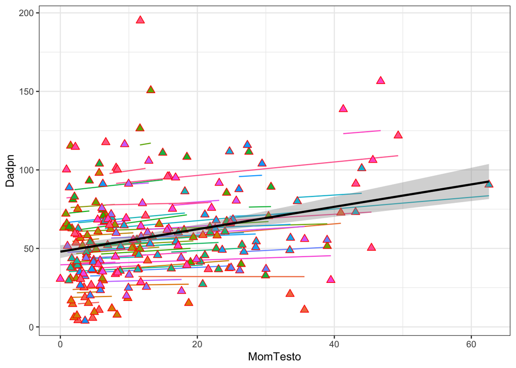

```r
augment(Model_daddy) %>%
  mutate(MomTesto = Mompn_pmc + Testo1pn_Average) %>%
  ggplot(aes(x = MomTesto, y = Dadpn, color = factor(CoupID))) +
  # Add points
  geom_point(size = 0.5, alpha = 0.2) +
  # Add within-cluster lines
  geom_smooth(aes(y = .fitted),
              method = "lm", se = FALSE, size = 0.5) +
  # Add group means
  stat_summary(aes(x = MomTesto, y = Dadpn,
                   fill = factor(CoupID)),
               color = "red",  # add border
               fun = mean,
               geom = "point",
               shape = 24,
               # use triangles
               size = 2.5) +
  # Add between coefficient
  geom_smooth(aes(x = MomTesto, y = .fitted),
              method = "lm", se = TRUE,
              color = "black") +
  labs(y = "Dadpn") +
  # Suppress legend
  guides(color = FALSE, fill = FALSE)
```